# R Exercise 2 Analysis

## Task 1

Data wrangling exersize is in the data folder.

This dataset contains information about students and their attitude/strategy towards learning and their exam scores.

```r
data <- read.table("~/IODS-project/data/learning2014.csv", header = TRUE, sep = ",")
head(data)
```

```
##   Gender Age Attitude Points     Deep     Surf  Stra
## 1      F  53       37     25 3.583333 2.583333 3.375
## 2      M  55       31     12 2.916667 3.166667 2.750
## 3      F  49       25     24 3.500000 2.250000 3.625
## 4      M  53       35     10 3.500000 2.250000 3.125
## 5      M  49       37     22 3.666667 2.833333 3.625
## 6      F  38       38     21 4.750000 2.416667 3.625
```

```r
names(data)
```

```
## [1] "Gender"   "Age"      "Attitude" "Points"   "Deep"     "Surf"
## [7] "Stra"
```

```r
dim(data)
```

```
## [1] 183   7
```

There are 7 variables and 183 people.

## Task 2

```r
library(ggplot2)
summary(data)
```

```
##  Gender       Age           Attitude         Points           Deep
##  F:122   Min.   :17.00   Min.   :14.00   Min.   : 0.00   Min.   :1.583
##  M: 61   1st Qu.:21.00   1st Qu.:26.00   1st Qu.:18.00   1st Qu.:3.333
##          Median :22.00   Median :32.00   Median :22.00   Median :3.667
##          Mean   :25.58   Mean   :31.21   Mean   :20.61   Mean   :3.696
##          3rd Qu.:27.00   3rd Qu.:37.00   3rd Qu.:26.00   3rd Qu.:4.083
##          Max.   :55.00   Max.   :50.00   Max.   :33.00   Max.   :4.917
##       Surf            Stra
##  Min.   :1.583   Min.   :1.250
##  1st Qu.:2.417   1st Qu.:2.562
##  Median :2.833   Median :3.125
##  Mean   :2.792   Mean   :3.085
##  3rd Qu.:3.167   3rd Qu.:3.625
##  Max.   :4.333   Max.   :5.000
```

Summary of all variables. Dataset is about students (Age, Gender) and their attitudes towards learning (Attitude, Deep, Stra, Surf) and their combined scores (Points). Combination stats like Deep/Surf/Stra combine several questions from the questionairre togetger.

Deep is a combination of questionaire questions that reflect “Deep Approach” to learning. (Seeking Meaning, Relating Ideas, Use of Evidence)

Surf is a “Surface Approach” to learning. (Lack of Purpose, Unrelated Memorizing, Syllabus-boundness)

Stra is a “Strategic Approach” to learning. (Organized Studying, Time Management)

I will use the graphical library ggplot to do graphics.

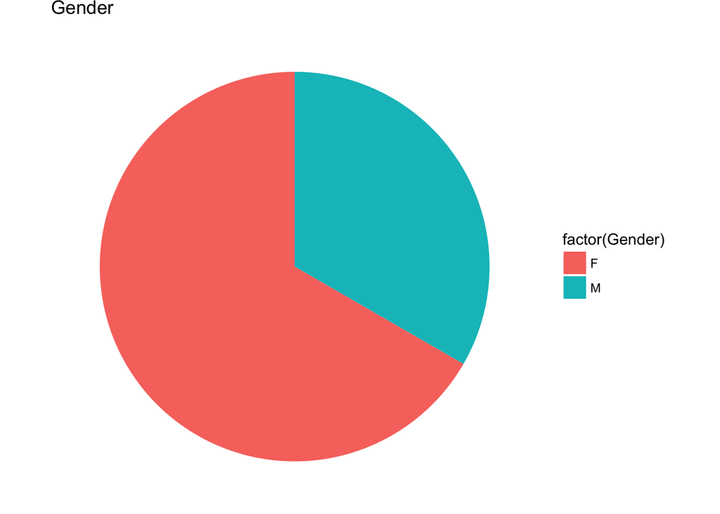

```r
#Pie chart of gender
ggplot(data, aes(x=factor(1), fill = factor(Gender)))+geom_bar(width=1)+coord_polar(theta="y")+theme_void()+labs(title="Gender")
```

There are 122 females and 61 males.

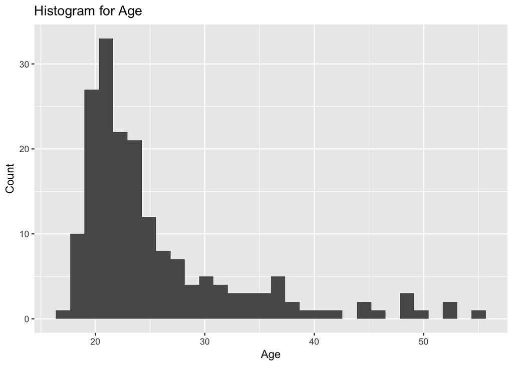

```r
#Histogram of Age
qplot(data$Age, geom="histogram")+labs(title="Histogram for Age") +
  labs(x="Age", y="Count")
```

Age distribution is slanted, there are a lot more people in their 20’s than other people. Age groups cannot really be compared directly because the amount of people are so different.

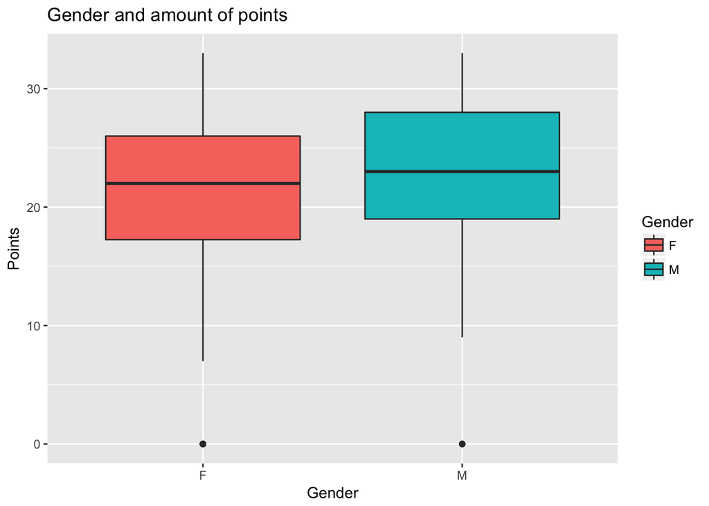

```r
#Boxplot of gender and points

ggplot(data, aes(x=Gender, y=Points, fill=Gender)) +
  geom_boxplot()+labs(title="Gender and amount of points")
```

Points and Attitude:

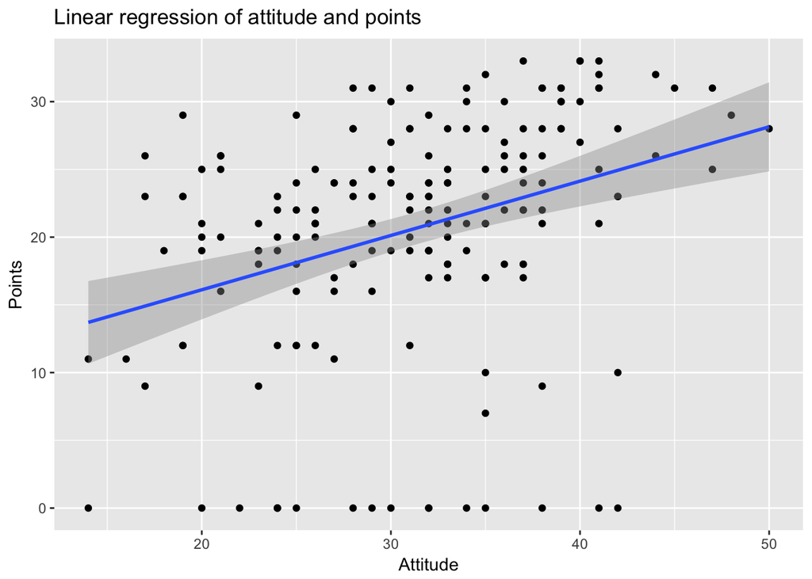

```r
#Linear regression of Attitude and Points
ggplot(data, aes(x = Attitude, y = Points)) + geom_point() + geom_smooth(method="lm")+labs(title="Linear regression of attitude and points")
```

```r
cor.test(data$Attitude, data$Points, method="pearson")
```

```
##
##  Pearson's product-moment correlation
##
## data:  data$Attitude and data$Points
## t = 4.8513, df = 181, p-value = 2.635e-06
## alternative hypothesis: true correlation is not equal to 0
## 95 percent confidence interval:
##  0.2042082 0.4615619
## sample estimates:
##       cor
## 0.3392167
```

Test of simple linear regression. Pearson correlation is significant and low positive, 0.339. (Pearson correlation assumes normalcy, not sure if it applies here)

Scatter plot matrix:

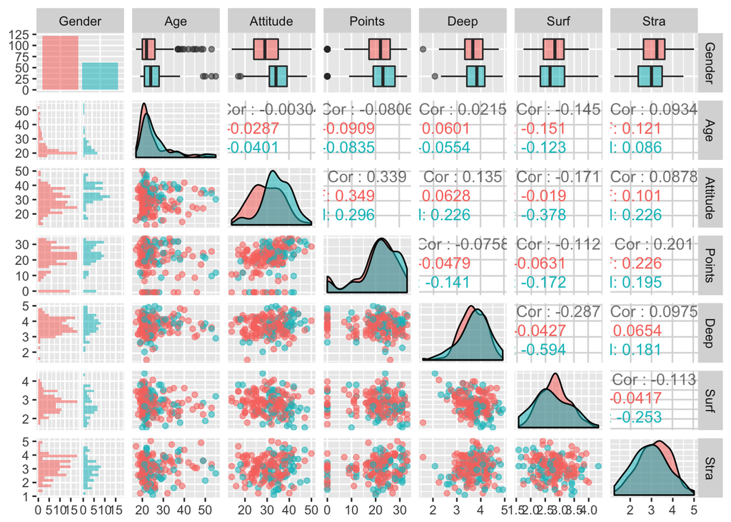

```r
library(GGally)
p <- ggpairs(data, mapping = aes(col=Gender, alpha=0.3), lower = list(combo = wrap("facethist", bins = 20)))
p
```

Compilation of all sorts of different statistics.

## Task 3 & 4

### Task 3

Target: Points

```r
linear <- lm(Points ~ Gender+Age+Attitude, data=data)
summary(linear)
```

```
##
## Call:
## lm(formula = Points ~ Gender + Age + Attitude, data = data)
##
## Residuals:
##     Min      1Q  Median      3Q     Max
## -25.153  -2.520   1.716   5.411  13.022
##
## Coefficients:
##             Estimate Std. Error t value Pr(>|t|)
## (Intercept) 10.23020    3.39239   3.016  0.00294 **
## GenderM     -0.39852    1.35699  -0.294  0.76934
## Age         -0.08766    0.07944  -1.103  0.27133
## Attitude     0.40862    0.08707   4.693 5.33e-06 ***
## ---
## Signif. codes:  0 '***' 0.001 '**' 0.01 '*' 0.05 '.' 0.1 ' ' 1
##
## Residual standard error: 8.196 on 179 degrees of freedom
## Multiple R-squared:  0.1218, Adjusted R-squared:  0.1071
## F-statistic: 8.278 on 3 and 179 DF,  p-value: 3.465e-05
```

This correlation is not significant for gender and age, but is for attitude. I will keep Attitude and remove Gender, Age.

```r
summary(lm(Points~Attitude+Stra+Surf, data=data))
```

```
##
## Call:
## lm(formula = Points ~ Attitude + Stra + Surf, data = data)
##
## Residuals:
##     Min      1Q  Median      3Q     Max
## -25.151  -3.212   2.233   5.257  13.694
##
## Coefficients:
##             Estimate Std. Error t value Pr(>|t|)
## (Intercept)  4.77806    5.15767   0.926   0.3555
## Attitude     0.37570    0.08308   4.522 1.11e-05 ***
## Stra         1.89680    0.78318   2.422   0.0164 *
## Surf        -0.62623    1.14945  -0.545   0.5866
## ---
## Signif. codes:  0 '***' 0.001 '**' 0.01 '*' 0.05 '.' 0.1 ' ' 1
##
## Residual standard error: 8.082 on 179 degrees of freedom
## Multiple R-squared:  0.146,  Adjusted R-squared:  0.1317
## F-statistic:  10.2 on 3 and 179 DF,  p-value: 3.089e-06
```

Linear regression is significant for Attitude and Stra, but not Surf. Remove Surf.

### Task 4

```r
summary(lm(Points~Attitude+Stra+Deep, data=data))
```

```
##
## Call:
## lm(formula = Points ~ Attitude + Stra + Deep, data = data)
##
## Residuals:
##     Min      1Q  Median      3Q     Max
## -23.499  -2.557   1.755   5.097  15.420
##
## Coefficients:
##             Estimate Std. Error t value Pr(>|t|)
## (Intercept)  9.69651    4.84553   2.001  0.04689 *
## Attitude     0.40408    0.08178   4.941 1.78e-06 ***
## Stra         2.07504    0.77411   2.681  0.00804 **
## Deep        -2.19240    1.08585  -2.019  0.04497 *
## ---
## Signif. codes:  0 '***' 0.001 '**' 0.01 '*' 0.05 '.' 0.1 ' ' 1
##
## Residual standard error: 7.998 on 179 degrees of freedom
## Multiple R-squared:  0.1637, Adjusted R-squared:  0.1496
## F-statistic: 11.68 on 3 and 179 DF,  p-value: 5.036e-07
```

R-squared is a statistical measure of how close the data are to the fitted regression line. If the data formed linearly on the regression line, R-squared would be 1 or close to 1. Multiple R-squared is low and that says that these variables do not explain the whole variation in exam points. There are other factors that affect the distribution/orientation of the data.

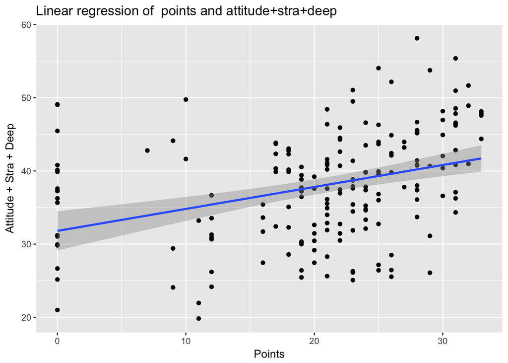

```r
ggplot(data, aes(x=Points, y=Attitude+Stra+Deep))+geom_point()+geom_smooth(method="lm")+labs(title="Linear regression of  points and attitude+stra+deep")
```

In the picture there’s slight positive linear correlation between Points and Attitude+Stra+Deep, meaning higher scores for an individual in Attitude+Stra+Deep generally mean there’s also a higher Points. While Points correlates with Attitude+Stra+Deep, those variables do not explain all variation in Points. Other factors that could affect points might be how familiar the student is with the course material previously and how much absolute time they spent on studying.

## Task 5

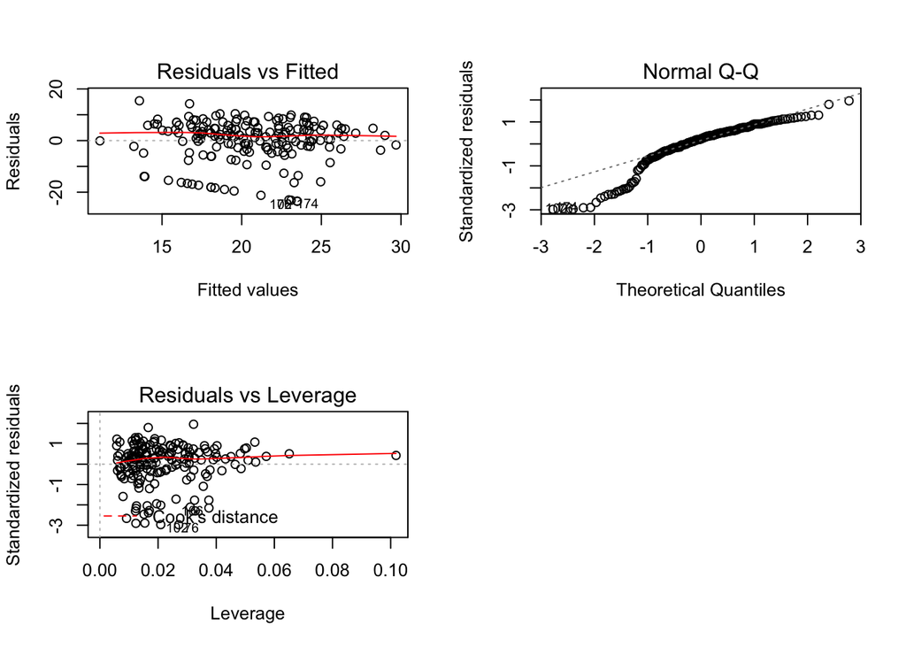

```r
linear <- lm(Points~Attitude+Stra+Deep, data=data)
par(mfrow = c(2,2))
plot(linear, which = c(1,2,5))
```

Q-Q Plot shows that the left tail of the distribution does not follow normalcy. It deviates a lot. I assume left tail contains all the “0 points” people, who answered the questions but possibly didn’t show up for the exam (0 points.) These people should be in a real analysis of the data.

There is also high spread in residuals, but they look mostly grouped linearly.

There is one higher leverage outlier in the data at 0.10 Leverage, while others are mostly between 0.0-0.04.